# Latihan MPDW Minggu 4

Ananda Putra Wijaya

2024-09-16

```r
library(TSA)
```

# White Noise MA

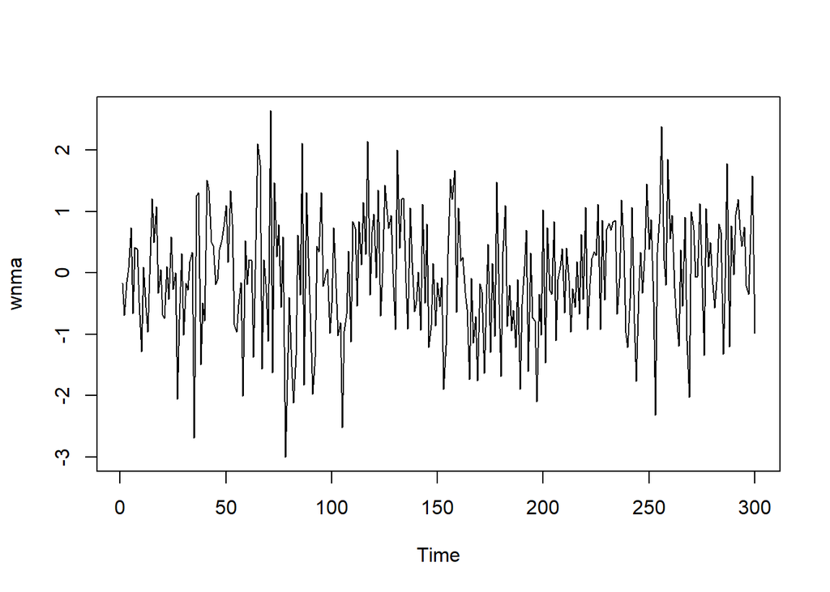

```r
set.seed(6666)
wnma <- rnorm(300)
ts.plot(wnma)
```

# MA(2)

Model MA(2) akan menggunakan data sebanyak 300 data. Model akan memiliki nilai $\theta_1 = 0.4$ dan $\theta_2 = 0.6$. Berikut merupakan model MA(2) yang akan digunakan

$$y_t = e_t-0.4e_{t-1}-0.6e_{t-2}$$

```r
ma<-c(1:300)
ma[1] <- wnma[1]
ma[2] <- ma[2] - 0.4 * ma[1]
```

```r
for(i in 3:300){
   ma[i] <- wnma[i] - 0.4 * wnma[i - 1] - 0.6 * wnma[i - 2]
}
ma
```

```
##   [1] -0.173339600  2.069335840  0.235624373  0.557761511  0.793352812
##   [6] -1.003927607  0.237093601  0.611575585 -0.888956357 -1.316816065
##  [11]  0.892987233  0.166879966 -0.793878172  0.701931954  1.799705216
##  [16]  0.024201526  0.156281084 -1.055965097 -0.467003987 -0.500704576
##  [21] -0.500017778  0.805535688 -0.029700122  0.693684631 -0.242115188
##  [26] -0.235979574 -1.898631083  0.058789926  1.855509382 -0.683555591
##  [31]  0.045473237  0.399145455  0.394087042  0.429489230 -2.935893300
##  [36]  2.136880799  2.422409385 -2.773597713 -0.679659545  0.310202351
##  [41]  2.114959986  1.212109104 -0.936680227 -0.571142793 -0.672035192
##  [46] -0.291043331  0.534628947  0.441114800  0.306558326  0.484756007
##  [51] -0.719505589  0.615355566  0.156029388 -1.966235581 -1.103127537
##  [56]  0.371401216  0.624908938 -1.637335886  1.425089958  0.806661526
##  [61] -0.028417416  0.238315414 -1.583555637  0.959139397  2.711159706
##  [66]  0.603834800 -3.531732327 -0.214022520  0.529699856 -1.115847913
##  [71]  3.282926780 -2.012751277  0.534011960  0.655290502 -0.202229278
```

[output cut: 45 more lines]

Model MA(2) dapat juga dibangkitkan dengan menggunakan fungsi `arima.sim()`

```r
ma2 <- arima.sim(list(order=c(0,0,2), ma=c(0.4, 0.6)), n=300)
ma2
```

```
## Time Series:
## Start = 1
## End = 300
## Frequency = 1
##   [1]  1.437455835  0.147354727  0.053310563  0.531554791  0.199283433
##   [6]  2.384604365  0.799730996  1.633075067  1.106464354 -0.314342137
##  [11] -0.798072745  0.757978846  1.773010015  2.291966470  2.600724432
##  [16]  1.914001113  0.238363943 -0.238746744  0.283738149  1.000558374
##  [21]  0.444457471  1.902232033  0.477290328  0.343735615 -0.896348391
##  [26] -1.014580817 -1.616085234 -1.937630289  0.286026585  1.563543355
##  [31]  2.023511557  1.185679704 -0.444185244  1.631058567  0.516310225
##  [36]  1.749428448  2.536169106  1.506901049 -0.002192880  1.119733552
##  [41]  0.070809776  1.456800508 -0.102243480 -1.328492152 -1.124274216
##  [46] -1.600323132 -1.307335341  0.477442602 -1.767469977 -1.345807259
##  [51] -0.666129367 -1.382678372  0.069793430 -0.386281849  0.959850574
```

[output cut: 49 more lines]

## Karakteristik MA(2)

### Plot DW MA(2)

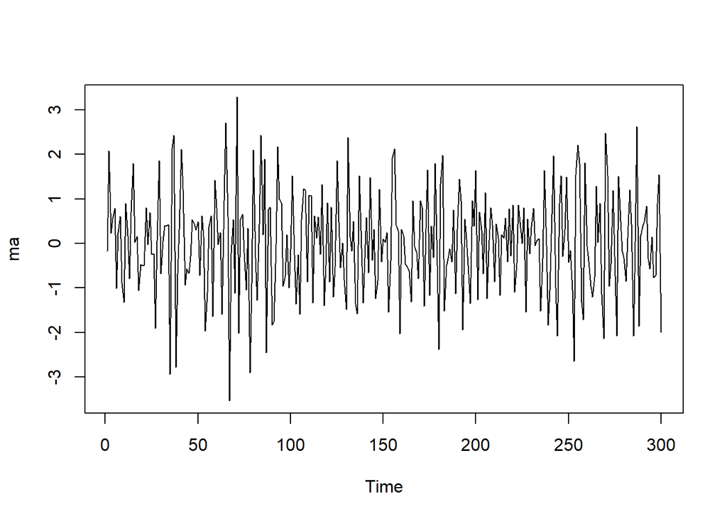

```r
ts.plot(ma)
```

Plot deret waktu menunjukkan bahwa data MA(2) stasioner pada rataan

### Plot ACF MA(2)

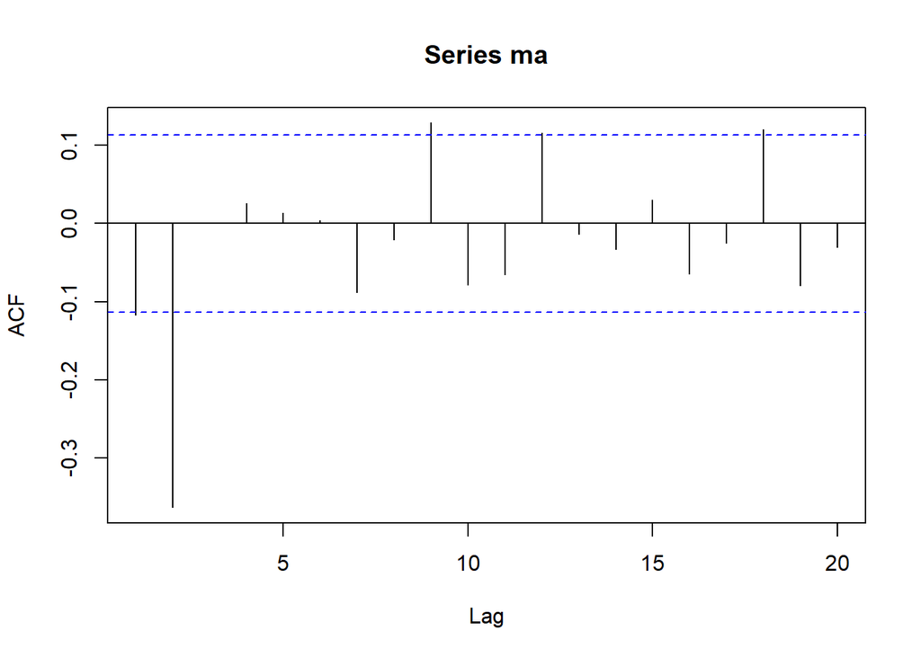

```r
acf(ma,lag.max = 20)
```

Pada plot AFC model MA(2), terlihat bahwa plot ACF *cuts off* di lag kedua

### Plot PACF MA(2)

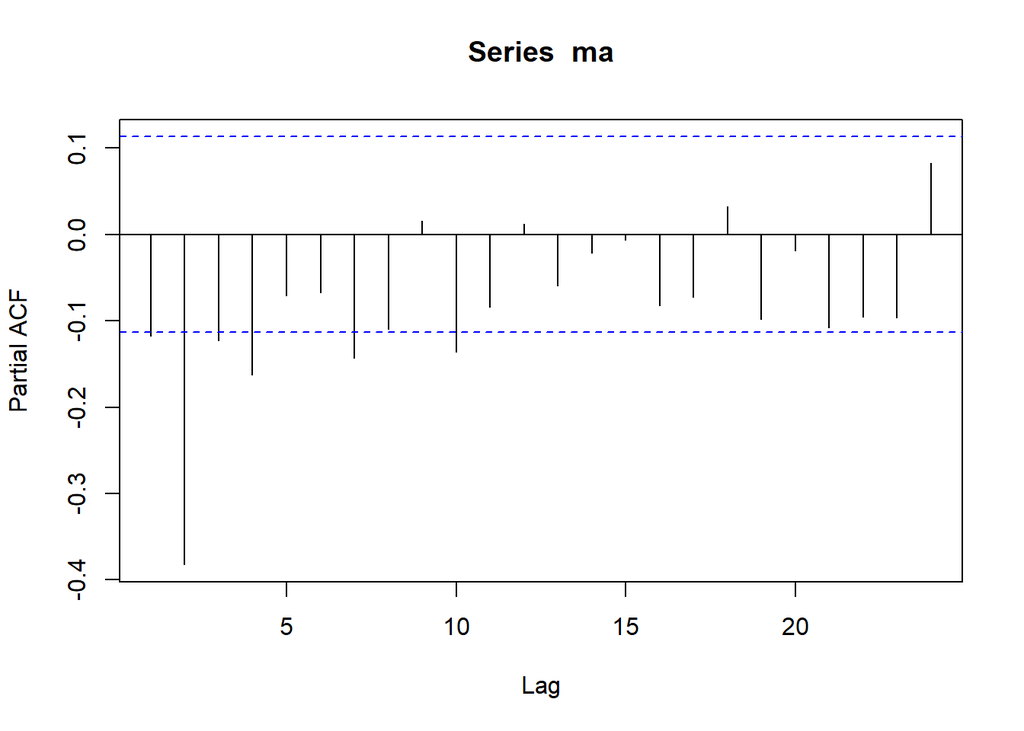

```r
pacf(ma)
```

Berdasarkan plot PACF tersebut, terlihat bahwa plot PACF MA(2) cenderung *tails off* dan membentuk gelombang lembah karena nilai teta adalah positif

### Plot EACF MA(2)

```r
eacf(ma)
```

```
## AR/MA
##   0 1 2 3 4 5 6 7 8 9 10 11 12 13
## 0 x x o o o o o o x o o  o  o  o
## 1 x x o o o o o o o o o  o  o  o
## 2 x x x o o o o o o o o  o  o  o
## 3 x x o o o o o o o o o  o  o  o
## 4 x x o o x o o o o o o  o  o  o
## 5 x o x o o o o o o o o  o  o  o
## 6 x x x x o o o x o o o  o  o  o
## 7 x x x x x o o x o o o  o  o  o
```

Berdasarkan pola segitiga nol pada plot EACF, terlihat bahwa segitiga nol berada pada ordo AR(0) dan ordo MA(2)

### Scatter plot Antar Lag untuk MA(2)

#### $Y_t$ dengan $Y_{t-1}$

```r
yt_ma <- ma[-1]
yt_ma
```

```
##   [1]  2.069335840  0.235624373  0.557761511  0.793352812 -1.003927607
##   [6]  0.237093601  0.611575585 -0.888956357 -1.316816065  0.892987233
##  [11]  0.166879966 -0.793878172  0.701931954  1.799705216  0.024201526
##  [16]  0.156281084 -1.055965097 -0.467003987 -0.500704576 -0.500017778
##  [21]  0.805535688 -0.029700122  0.693684631 -0.242115188 -0.235979574
##  [26] -1.898631083  0.058789926  1.855509382 -0.683555591  0.045473237
##  [31]  0.399145455  0.394087042  0.429489230 -2.935893300  2.136880799
##  [36]  2.422409385 -2.773597713 -0.679659545  0.310202351  2.114959986
##  [41]  1.212109104 -0.936680227 -0.571142793 -0.672035192 -0.291043331
##  [46]  0.534628947  0.441114800  0.306558326  0.484756007 -0.719505589
##  [51]  0.615355566  0.156029388 -1.966235581 -1.103127537  0.371401216
##  [56]  0.624908938 -1.637335886  1.425089958  0.806661526 -0.028417416
##  [61]  0.238315414 -1.583555637  0.959139397  2.711159706  0.603834800
##  [66] -3.531732327 -0.214022520  0.529699856 -1.115847913  3.282926780
##  [71] -2.012751277  0.534011960  0.655290502 -0.202229278 -1.038755988
```

[output cut: 45 more lines]

```r
yt_1_ma <- ma[-300]
yt_1_ma
```

```
##   [1] -0.173339600  2.069335840  0.235624373  0.557761511  0.793352812
##   [6] -1.003927607  0.237093601  0.611575585 -0.888956357 -1.316816065
##  [11]  0.892987233  0.166879966 -0.793878172  0.701931954  1.799705216
##  [16]  0.024201526  0.156281084 -1.055965097 -0.467003987 -0.500704576
##  [21] -0.500017778  0.805535688 -0.029700122  0.693684631 -0.242115188
##  [26] -0.235979574 -1.898631083  0.058789926  1.855509382 -0.683555591
##  [31]  0.045473237  0.399145455  0.394087042  0.429489230 -2.935893300
##  [36]  2.136880799  2.422409385 -2.773597713 -0.679659545  0.310202351
##  [41]  2.114959986  1.212109104 -0.936680227 -0.571142793 -0.672035192
##  [46] -0.291043331  0.534628947  0.441114800  0.306558326  0.484756007
##  [51] -0.719505589  0.615355566  0.156029388 -1.966235581 -1.103127537
##  [56]  0.371401216  0.624908938 -1.637335886  1.425089958  0.806661526
##  [61] -0.028417416  0.238315414 -1.583555637  0.959139397  2.711159706
##  [66]  0.603834800 -3.531732327 -0.214022520  0.529699856 -1.115847913
##  [71]  3.282926780 -2.012751277  0.534011960  0.655290502 -0.202229278
```

[output cut: 45 more lines]

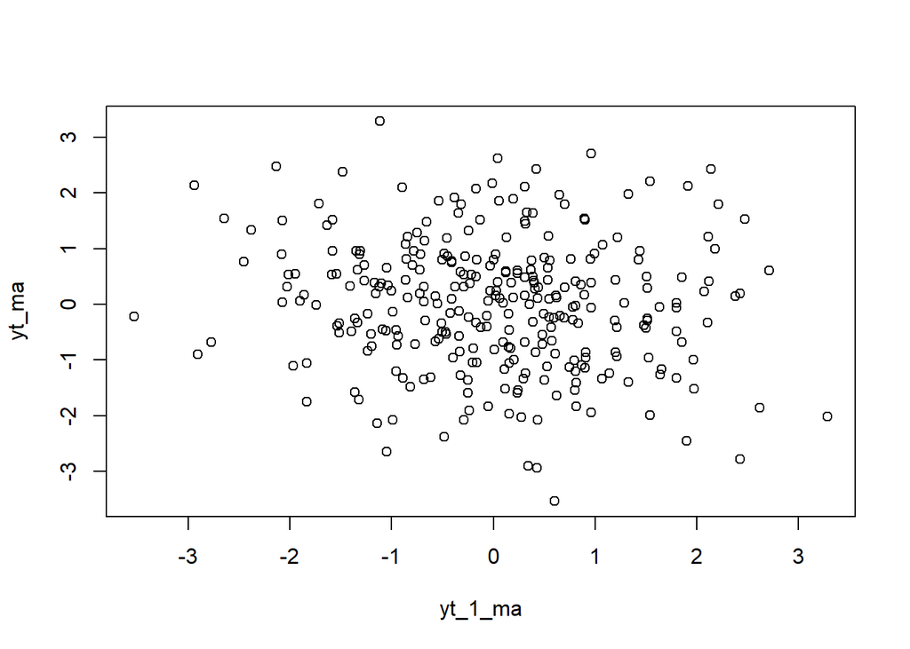

```r
plot(y=yt_ma,x=yt_1_ma)
```

Scatter plot $Y_t$ dengan $Y_{t-1}$ menunjukkan bahwa terdapat hubungan negatif antara $Y_t$ dengan $Y_{t-1}$.

```r
cor(yt_ma,yt_1_ma)
```

```
## [1] -0.1177605
```

Nilai korelasi$Y_t$ dengan $Y_{t-1}$ pada hasil simulasi mendekati perhitungan teoritis yaitu

$$\rho_1=\frac{-\theta_1+\theta_1\theta_2}{1+\theta_1^2+\theta_2^2}=\frac{-0.4+0.4\times0.6}{1+0.4^2+0.6^2}
\approx-0.105$$

#### $Y_t$ dengan $Y_{t-2}$

```r
yt_ma2 <- ma[-c(1,2)]
yt_ma2
```

```
##   [1]  0.235624373  0.557761511  0.793352812 -1.003927607  0.237093601
##   [6]  0.611575585 -0.888956357 -1.316816065  0.892987233  0.166879966
##  [11] -0.793878172  0.701931954  1.799705216  0.024201526  0.156281084
##  [16] -1.055965097 -0.467003987 -0.500704576 -0.500017778  0.805535688
##  [21] -0.029700122  0.693684631 -0.242115188 -0.235979574 -1.898631083
##  [26]  0.058789926  1.855509382 -0.683555591  0.045473237  0.399145455
##  [31]  0.394087042  0.429489230 -2.935893300  2.136880799  2.422409385
##  [36] -2.773597713 -0.679659545  0.310202351  2.114959986  1.212109104
##  [41] -0.936680227 -0.571142793 -0.672035192 -0.291043331  0.534628947
##  [46]  0.441114800  0.306558326  0.484756007 -0.719505589  0.615355566
##  [51]  0.156029388 -1.966235581 -1.103127537  0.371401216  0.624908938
##  [56] -1.637335886  1.425089958  0.806661526 -0.028417416  0.238315414
##  [61] -1.583555637  0.959139397  2.711159706  0.603834800 -3.531732327
##  [66] -0.214022520  0.529699856 -1.115847913  3.282926780 -2.012751277
##  [71]  0.534011960  0.655290502 -0.202229278 -1.038755988  0.341458963
```

[output cut: 45 more lines]

```r
yt_2_ma <- ma[-c(299,300)]
yt_2_ma
```

```
##   [1] -0.173339600  2.069335840  0.235624373  0.557761511  0.793352812
##   [6] -1.003927607  0.237093601  0.611575585 -0.888956357 -1.316816065
##  [11]  0.892987233  0.166879966 -0.793878172  0.701931954  1.799705216
##  [16]  0.024201526  0.156281084 -1.055965097 -0.467003987 -0.500704576
##  [21] -0.500017778  0.805535688 -0.029700122  0.693684631 -0.242115188
##  [26] -0.235979574 -1.898631083  0.058789926  1.855509382 -0.683555591
##  [31]  0.045473237  0.399145455  0.394087042  0.429489230 -2.935893300
##  [36]  2.136880799  2.422409385 -2.773597713 -0.679659545  0.310202351
##  [41]  2.114959986  1.212109104 -0.936680227 -0.571142793 -0.672035192
##  [46] -0.291043331  0.534628947  0.441114800  0.306558326  0.484756007
##  [51] -0.719505589  0.615355566  0.156029388 -1.966235581 -1.103127537
##  [56]  0.371401216  0.624908938 -1.637335886  1.425089958  0.806661526
##  [61] -0.028417416  0.238315414 -1.583555637  0.959139397  2.711159706
##  [66]  0.603834800 -3.531732327 -0.214022520  0.529699856 -1.115847913
##  [71]  3.282926780 -2.012751277  0.534011960  0.655290502 -0.202229278
```

[output cut: 45 more lines]

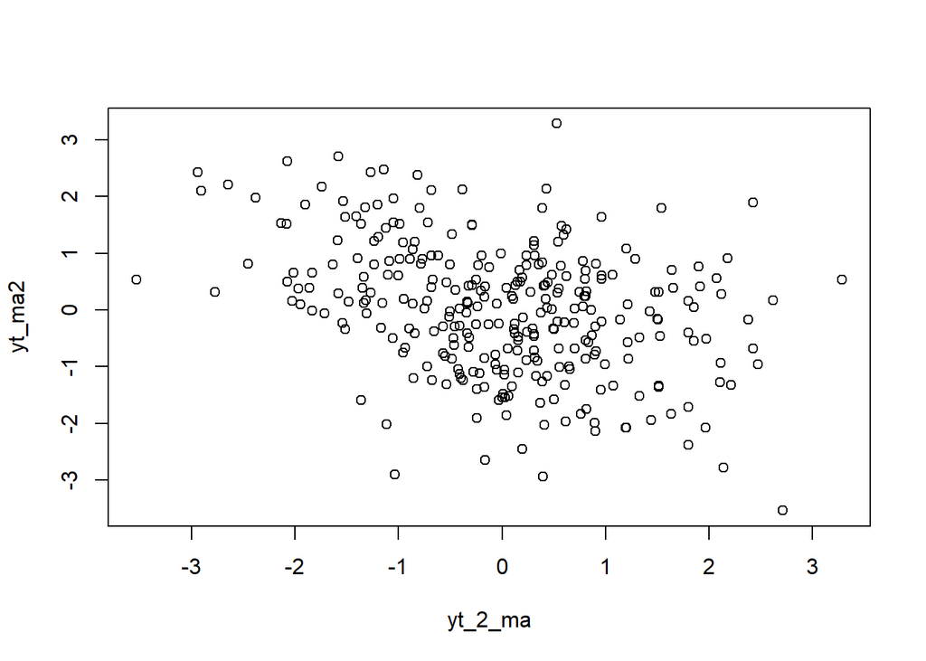

```r
plot(y=yt_ma2,x=yt_2_ma)
```

Scatter plot $Y_t$ dengan $Y_{t-2}$ menunjukkan bahwa terdapat hubungan negatif antara $Y_t$ dengan $Y_{t-2}$.

```r
cor(yt_ma2,yt_2_ma)
```

```
## [1] -0.3681722
```

Korelasi antara $Y_t$ dengan $Y_{t-2}$ dari hasil simulasi relatif mendekati perhitungan teoritis yaitu

$$\rho_2=\frac{-\theta_2}{1+\theta_1^2+\theta_2^2}=\frac{-0.6}{1+0.4^2+0.6^2}\approx-0.394$$

#### $Y_t$ dengan $Y_{t-3}$

```r
yt_ma3 <- ma[-c(1,2,3)]
yt_ma3
```

```
##   [1]  0.557761511  0.793352812 -1.003927607  0.237093601  0.611575585
##   [6] -0.888956357 -1.316816065  0.892987233  0.166879966 -0.793878172
##  [11]  0.701931954  1.799705216  0.024201526  0.156281084 -1.055965097
##  [16] -0.467003987 -0.500704576 -0.500017778  0.805535688 -0.029700122
##  [21]  0.693684631 -0.242115188 -0.235979574 -1.898631083  0.058789926
##  [26]  1.855509382 -0.683555591  0.045473237  0.399145455  0.394087042
##  [31]  0.429489230 -2.935893300  2.136880799  2.422409385 -2.773597713
##  [36] -0.679659545  0.310202351  2.114959986  1.212109104 -0.936680227
##  [41] -0.571142793 -0.672035192 -0.291043331  0.534628947  0.441114800
##  [46]  0.306558326  0.484756007 -0.719505589  0.615355566  0.156029388
##  [51] -1.966235581 -1.103127537  0.371401216  0.624908938 -1.637335886
##  [56]  1.425089958  0.806661526 -0.028417416  0.238315414 -1.583555637
##  [61]  0.959139397  2.711159706  0.603834800 -3.531732327 -0.214022520
##  [66]  0.529699856 -1.115847913  3.282926780 -2.012751277  0.534011960
##  [71]  0.655290502 -0.202229278 -1.038755988  0.341458963 -2.903103880
```

[output cut: 45 more lines]

```r
yt_3_ma <- ma[-c(288, 299,300)]
yt_3_ma
```

```
##   [1] -0.173339600  2.069335840  0.235624373  0.557761511  0.793352812
##   [6] -1.003927607  0.237093601  0.611575585 -0.888956357 -1.316816065
##  [11]  0.892987233  0.166879966 -0.793878172  0.701931954  1.799705216
##  [16]  0.024201526  0.156281084 -1.055965097 -0.467003987 -0.500704576
##  [21] -0.500017778  0.805535688 -0.029700122  0.693684631 -0.242115188
##  [26] -0.235979574 -1.898631083  0.058789926  1.855509382 -0.683555591
##  [31]  0.045473237  0.399145455  0.394087042  0.429489230 -2.935893300
##  [36]  2.136880799  2.422409385 -2.773597713 -0.679659545  0.310202351
##  [41]  2.114959986  1.212109104 -0.936680227 -0.571142793 -0.672035192
##  [46] -0.291043331  0.534628947  0.441114800  0.306558326  0.484756007
##  [51] -0.719505589  0.615355566  0.156029388 -1.966235581 -1.103127537
##  [56]  0.371401216  0.624908938 -1.637335886  1.425089958  0.806661526
##  [61] -0.028417416  0.238315414 -1.583555637  0.959139397  2.711159706
##  [66]  0.603834800 -3.531732327 -0.214022520  0.529699856 -1.115847913
##  [71]  3.282926780 -2.012751277  0.534011960  0.655290502 -0.202229278
```

[output cut: 45 more lines]

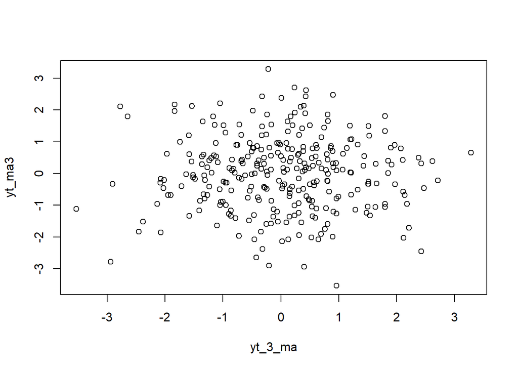

```r
plot(y=yt_ma3,x=yt_3_ma)
```

Scatter plot di atas menggambarkan pola $Y_t$ dan $Y_{t-3}$. Kita dapat lihat bahwa $Y_t$ dan $Y_{t-3}$ tidak menunjukkan pola yang beraturan atau dapat disebut tidak berpola.

```r
cor(yt_ma3,yt_3_ma)
```

```
## [1] -0.008550618
```

Korelasi antara $Y_t$ dengan $Y_{t-3}$ mendekati nilai teoritis yang menyatakan bahwa $\rho_k=0$ untuk k>q

# White Noise AR

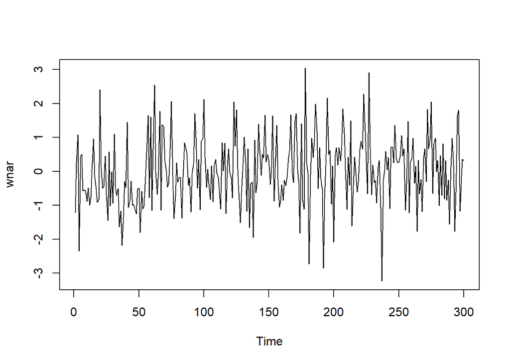

```r
set.seed(1234)
wnar <- rnorm(300)
ts.plot(wnar)
```

# AR(2)

Model AR(2) akan menggunakan data sebanyak 300 data. Model akan memiliki nilai $\phi_1 = 0.5$ dan $\phi_2 = 0.2$. Berikut merupakan model AR(2) yang akan digunakan

$$Y_t = e_t+0.5Y_{t-1}+0.2Y_{t-2}$$

```r
ar<-c(1:300)
ar[1] <- wnar[1]
ar[2] <- wnar[2] + 0.5 * ar[1]
```

```r
for (i in 3:300) {
  ar[i] <- wnar[i] + 0.5 * ar[i-1] + 0.2 * ar[i-2]
}
ar
```

```
##   [1] -1.207065749 -0.326103633  0.679976211 -2.070930324 -0.470345231
##   [6] -0.143302788 -0.740460400 -0.945522614 -1.185305386 -1.671795045
##  [11] -1.550151299 -2.107821103 -2.140194706 -1.427202757 -0.182146261
##  [16] -0.486799176 -0.790838346 -1.403974425 -1.697326562  1.286377013
##  [21]  0.437811414 -0.014504787 -0.360237983  0.276569492 -0.627483098
##  [26] -1.706632561 -0.404057179 -1.567010825 -0.879455148 -1.689078340
##  [31]  0.081867346 -0.772475074 -1.079304105 -1.195405128 -2.442656854
##  [36] -2.628028715 -3.982585377 -3.857891624 -3.019756746 -2.747354238
##  [41] -0.528132203 -1.882179673 -1.902080911 -1.608099392 -2.178805954
##  [46] -2.379537173 -2.732847970 -3.094317305 -2.617556366 -2.424491601
##  [51] -3.541788331 -2.837868410 -3.236181496 -3.200626439 -2.409859042
##  [56] -1.281998990  0.524846169 -0.767330137  1.327213794 -0.647667678
##  [61]  0.598197384  2.718556227  1.444157201  0.596156266  0.579304817
##  [66]  2.185968110  0.070237282  1.840139442  2.263681968  1.836341670
##  [71]  1.377800067  0.600699629  0.209385895  0.873119441  2.548707761
```

[output cut: 45 more lines]

Model AR(2) dapat juga dibangkitkan dengan menggunakan fungsi `arima.sim()`

```r
ar2 <- arima.sim(list(order=c(2,0,0), ar=c(0.5,0.2)), n=300)
ar2
```

```
## Time Series:
## Start = 1
## End = 300
## Frequency = 1
##   [1] -1.51198789  0.14622636 -1.18196985  0.56474307 -0.60306545  0.10388597
##   [7]  0.83003262 -0.08294885  0.67897065  0.23492188 -0.88195786 -0.66407416
##  [13]  1.11136122  0.20873461 -0.49114292 -0.25784746  0.10298930  0.95524977
##  [19]  1.64218262  1.11266366  2.04934360  0.48294459 -1.69317239 -1.22168070
##  [25] -1.46533032 -3.29303745 -1.37711303 -2.13093915 -1.56694617 -2.79676390
##  [31] -1.16424698  0.74975075 -0.73605113 -0.33063433  1.63618567  1.68578230
##  [37]  3.08318771  1.87351626  1.40113562  0.56563940  1.99762053 -0.17390039
##  [43]  0.61988813  0.22884545  2.49024215  0.68285644 -0.66981152  0.03429730
##  [49] -0.15646235 -0.91049678 -0.35424977 -0.63474899 -1.06698309 -0.15960541
##  [55] -0.62486164 -2.17933215 -3.86637965 -2.94963843 -0.79390827 -0.14875244
##  [61]  0.98189570  1.44370281  1.23399457 -0.60132478  0.15170631  1.55281629
```

[output cut: 39 more lines]

## Karakteristik AR(2)

### Plot DW AR(2)

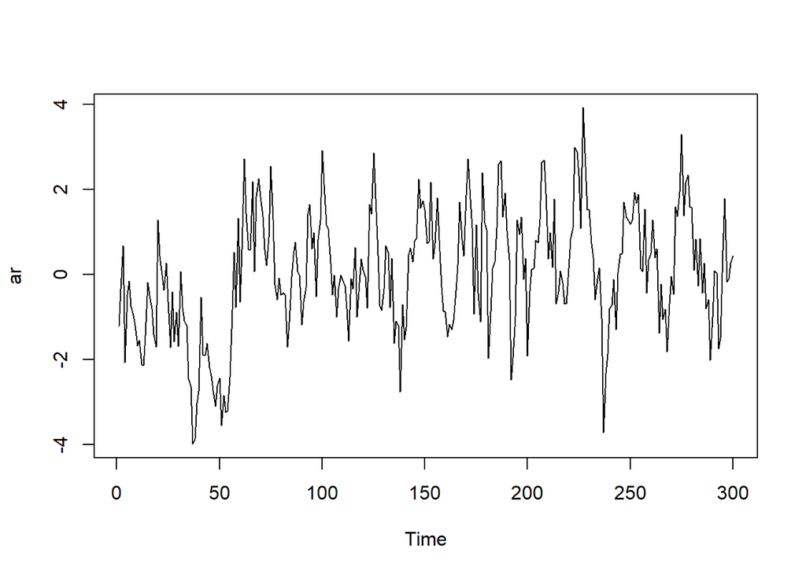

```r
ts.plot(ar)
```

Plot deret waktu menunjukkan bahwa data AR(2) stasioner cenderung stasioner pada rataan

### Plot ACF AR(2)

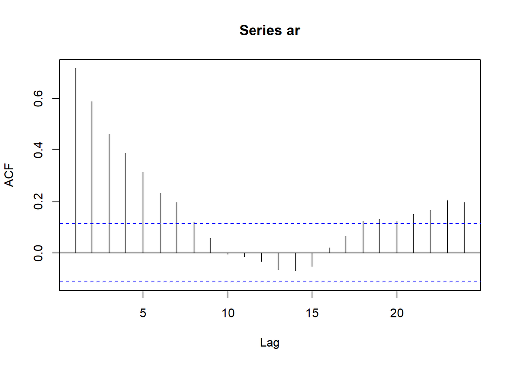

```r
acf(ar)
```

Berdasarkan plot ACF tersebut terlihat bahwa plot ACF AR(2) cenderung *tails off*

### Plot PACF AR(2)

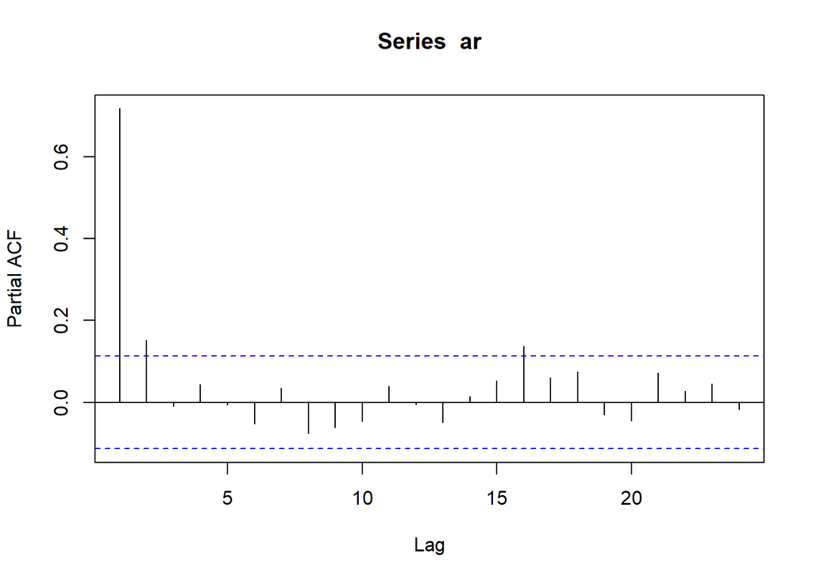

```r
pacf(ar)
```

Berdasarkan plot PACF tersebut, terlihat bahwa plot PACF AR(2) *cuts off* pada lag kedua

### Plot EACF AR(2)

```r
eacf(ar)
```

```
## AR/MA
##   0 1 2 3 4 5 6 7 8 9 10 11 12 13
## 0 x x x x x x x x o o o  o  o  o
## 1 x o o o o o o o o o o  o  o  o
## 2 o o o o o o o o o o o  o  o  o
## 3 x x o o o o o o o o o  o  o  o
## 4 x x o o o o o o o o o  o  o  o
## 5 o x o x o o x o o o o  o  o  o
## 6 x x x x o o o o o o o  o  o  o
## 7 x x x o x x o o o o o  o  o  o
```

Pada plot EACF di atas, terlihat bahwa segitiga nol berada pada ordo AR(2) dan ordo MA(0)

### Scatter plot Antar Lag untuk AR(2)

#### $Y_t$ dengan $Y_{t-1}$

```r
yt_ar <- ar[-1]
yt_ar
```

```
##   [1] -0.326103633  0.679976211 -2.070930324 -0.470345231 -0.143302788
##   [6] -0.740460400 -0.945522614 -1.185305386 -1.671795045 -1.550151299
##  [11] -2.107821103 -2.140194706 -1.427202757 -0.182146261 -0.486799176
##  [16] -0.790838346 -1.403974425 -1.697326562  1.286377013  0.437811414
##  [21] -0.014504787 -0.360237983  0.276569492 -0.627483098 -1.706632561
##  [26] -0.404057179 -1.567010825 -0.879455148 -1.689078340  0.081867346
##  [31] -0.772475074 -1.079304105 -1.195405128 -2.442656854 -2.628028715
##  [36] -3.982585377 -3.857891624 -3.019756746 -2.747354238 -0.528132203
##  [41] -1.882179673 -1.902080911 -1.608099392 -2.178805954 -2.379537173
##  [46] -2.732847970 -3.094317305 -2.617556366 -2.424491601 -3.541788331
##  [51] -2.837868410 -3.236181496 -3.200626439 -2.409859042 -1.281998990
##  [56]  0.524846169 -0.767330137  1.327213794 -0.647667678  0.598197384
##  [61]  2.718556227  1.444157201  0.596156266  0.579304817  2.185968110
##  [66]  0.070237282  1.840139442  2.263681968  1.836341670  1.377800067
##  [71]  0.600699629  0.209385895  0.873119441  2.548707761  1.295579356
```

[output cut: 45 more lines]

```r
yt_1_ar <- ar[-300]
yt_1_ar
```

```
##   [1] -1.207065749 -0.326103633  0.679976211 -2.070930324 -0.470345231
##   [6] -0.143302788 -0.740460400 -0.945522614 -1.185305386 -1.671795045
##  [11] -1.550151299 -2.107821103 -2.140194706 -1.427202757 -0.182146261
##  [16] -0.486799176 -0.790838346 -1.403974425 -1.697326562  1.286377013
##  [21]  0.437811414 -0.014504787 -0.360237983  0.276569492 -0.627483098
##  [26] -1.706632561 -0.404057179 -1.567010825 -0.879455148 -1.689078340
##  [31]  0.081867346 -0.772475074 -1.079304105 -1.195405128 -2.442656854
##  [36] -2.628028715 -3.982585377 -3.857891624 -3.019756746 -2.747354238
##  [41] -0.528132203 -1.882179673 -1.902080911 -1.608099392 -2.178805954
##  [46] -2.379537173 -2.732847970 -3.094317305 -2.617556366 -2.424491601
##  [51] -3.541788331 -2.837868410 -3.236181496 -3.200626439 -2.409859042
##  [56] -1.281998990  0.524846169 -0.767330137  1.327213794 -0.647667678
##  [61]  0.598197384  2.718556227  1.444157201  0.596156266  0.579304817
##  [66]  2.185968110  0.070237282  1.840139442  2.263681968  1.836341670
##  [71]  1.377800067  0.600699629  0.209385895  0.873119441  2.548707761
```

[output cut: 45 more lines]

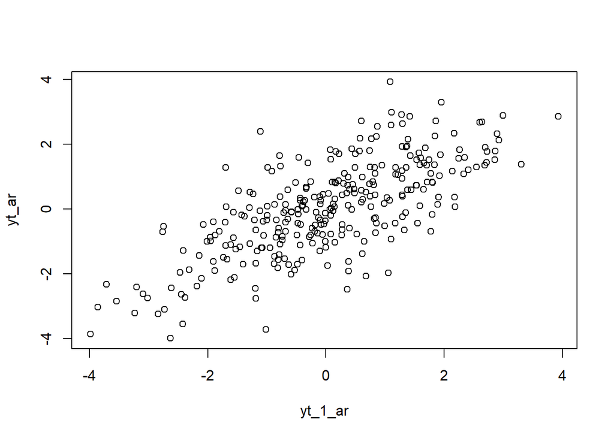

```r
plot(y=yt_ar,x=yt_1_ar)
```

Scatter plot $Y_t$ dengan $Y_{t-1}$ menunjukkan bahwa terdapat hubungan positif antara $Y_t$ dengan $Y_{t-1}$.

```r
cor(yt_ar,yt_1_ar)
```

```
## [1] 0.7181941
```

Korelasi antara $Y_t$ dengan $Y_{t-1}$ mendekati perhitungan teoritis yaitu

$$\rho_1=\frac{\phi_1}{1-\phi_2}=\frac{0.5}{1-0.2}=0.625$$

#### $Y_t$ dengan $Y_{t-2}$

```r
yt_ar2 <- ar[-c(1,2)]
yt_ar2
```

```
##   [1]  0.679976211 -2.070930324 -0.470345231 -0.143302788 -0.740460400
##   [6] -0.945522614 -1.185305386 -1.671795045 -1.550151299 -2.107821103
##  [11] -2.140194706 -1.427202757 -0.182146261 -0.486799176 -0.790838346
##  [16] -1.403974425 -1.697326562  1.286377013  0.437811414 -0.014504787
##  [21] -0.360237983  0.276569492 -0.627483098 -1.706632561 -0.404057179
##  [26] -1.567010825 -0.879455148 -1.689078340  0.081867346 -0.772475074
##  [31] -1.079304105 -1.195405128 -2.442656854 -2.628028715 -3.982585377
##  [36] -3.857891624 -3.019756746 -2.747354238 -0.528132203 -1.882179673
##  [41] -1.902080911 -1.608099392 -2.178805954 -2.379537173 -2.732847970
##  [46] -3.094317305 -2.617556366 -2.424491601 -3.541788331 -2.837868410
##  [51] -3.236181496 -3.200626439 -2.409859042 -1.281998990  0.524846169
##  [56] -0.767330137  1.327213794 -0.647667678  0.598197384  2.718556227
##  [61]  1.444157201  0.596156266  0.579304817  2.185968110  0.070237282
##  [66]  1.840139442  2.263681968  1.836341670  1.377800067  0.600699629
##  [71]  0.209385895  0.873119441  2.548707761  1.295579356 -0.233169716
```

[output cut: 45 more lines]

```r
yt_2_ar <- ar[-c(299,300)]
yt_2_ar
```

```
##   [1] -1.207065749 -0.326103633  0.679976211 -2.070930324 -0.470345231
##   [6] -0.143302788 -0.740460400 -0.945522614 -1.185305386 -1.671795045
##  [11] -1.550151299 -2.107821103 -2.140194706 -1.427202757 -0.182146261
##  [16] -0.486799176 -0.790838346 -1.403974425 -1.697326562  1.286377013
##  [21]  0.437811414 -0.014504787 -0.360237983  0.276569492 -0.627483098
##  [26] -1.706632561 -0.404057179 -1.567010825 -0.879455148 -1.689078340
##  [31]  0.081867346 -0.772475074 -1.079304105 -1.195405128 -2.442656854
##  [36] -2.628028715 -3.982585377 -3.857891624 -3.019756746 -2.747354238
##  [41] -0.528132203 -1.882179673 -1.902080911 -1.608099392 -2.178805954
##  [46] -2.379537173 -2.732847970 -3.094317305 -2.617556366 -2.424491601
##  [51] -3.541788331 -2.837868410 -3.236181496 -3.200626439 -2.409859042
##  [56] -1.281998990  0.524846169 -0.767330137  1.327213794 -0.647667678
##  [61]  0.598197384  2.718556227  1.444157201  0.596156266  0.579304817
##  [66]  2.185968110  0.070237282  1.840139442  2.263681968  1.836341670
##  [71]  1.377800067  0.600699629  0.209385895  0.873119441  2.548707761
```

[output cut: 45 more lines]

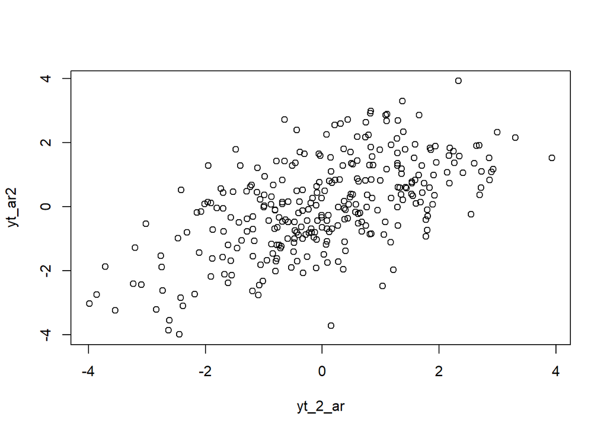

```r
plot(y=yt_ar2,x=yt_2_ar)
```

Scatter plot di atas menunjukkan bahwa terdapat hubungan positif antara $Y_t$ dengan $Y_{t-2}$.

```r
cor(yt_ar2,yt_2_ar)
```

```
## [1] 0.5889847
```

Korelasi antara $Y_t$ dengan $Y_{t-2}$ mendekati perhitungan teoritis yaitu

$$\rho_2=\phi_1\rho_{k-1}+\phi_2\rho_{k-2}=\frac{\phi_2(1-\phi_2)+\phi_1^2}{1-\phi_2}=\frac{0.2(1-0.2)+0.5^2}{1-0.2}=0.5125$$

#### $Y_t$ dengan $Y_{t-3}$

```r
yt_ar3 <- ar[-c(1,2,3)]
yt_ar3
```

```
##   [1] -2.070930324 -0.470345231 -0.143302788 -0.740460400 -0.945522614
##   [6] -1.185305386 -1.671795045 -1.550151299 -2.107821103 -2.140194706
##  [11] -1.427202757 -0.182146261 -0.486799176 -0.790838346 -1.403974425
##  [16] -1.697326562  1.286377013  0.437811414 -0.014504787 -0.360237983
##  [21]  0.276569492 -0.627483098 -1.706632561 -0.404057179 -1.567010825
##  [26] -0.879455148 -1.689078340  0.081867346 -0.772475074 -1.079304105
##  [31] -1.195405128 -2.442656854 -2.628028715 -3.982585377 -3.857891624
##  [36] -3.019756746 -2.747354238 -0.528132203 -1.882179673 -1.902080911
##  [41] -1.608099392 -2.178805954 -2.379537173 -2.732847970 -3.094317305
##  [46] -2.617556366 -2.424491601 -3.541788331 -2.837868410 -3.236181496
##  [51] -3.200626439 -2.409859042 -1.281998990  0.524846169 -0.767330137
##  [56]  1.327213794 -0.647667678  0.598197384  2.718556227  1.444157201
##  [61]  0.596156266  0.579304817  2.185968110  0.070237282  1.840139442
##  [66]  2.263681968  1.836341670  1.377800067  0.600699629  0.209385895
##  [71]  0.873119441  2.548707761  1.295579356 -0.233169716 -0.581050764
```

[output cut: 45 more lines]

```r
yt_3_ar <- ar[-c(298,299,300)]
yt_3_ar
```

```
##   [1] -1.207065749 -0.326103633  0.679976211 -2.070930324 -0.470345231
##   [6] -0.143302788 -0.740460400 -0.945522614 -1.185305386 -1.671795045
##  [11] -1.550151299 -2.107821103 -2.140194706 -1.427202757 -0.182146261
##  [16] -0.486799176 -0.790838346 -1.403974425 -1.697326562  1.286377013
##  [21]  0.437811414 -0.014504787 -0.360237983  0.276569492 -0.627483098
##  [26] -1.706632561 -0.404057179 -1.567010825 -0.879455148 -1.689078340
##  [31]  0.081867346 -0.772475074 -1.079304105 -1.195405128 -2.442656854
##  [36] -2.628028715 -3.982585377 -3.857891624 -3.019756746 -2.747354238
##  [41] -0.528132203 -1.882179673 -1.902080911 -1.608099392 -2.178805954
##  [46] -2.379537173 -2.732847970 -3.094317305 -2.617556366 -2.424491601
##  [51] -3.541788331 -2.837868410 -3.236181496 -3.200626439 -2.409859042
##  [56] -1.281998990  0.524846169 -0.767330137  1.327213794 -0.647667678
##  [61]  0.598197384  2.718556227  1.444157201  0.596156266  0.579304817
##  [66]  2.185968110  0.070237282  1.840139442  2.263681968  1.836341670
##  [71]  1.377800067  0.600699629  0.209385895  0.873119441  2.548707761
```

[output cut: 45 more lines]

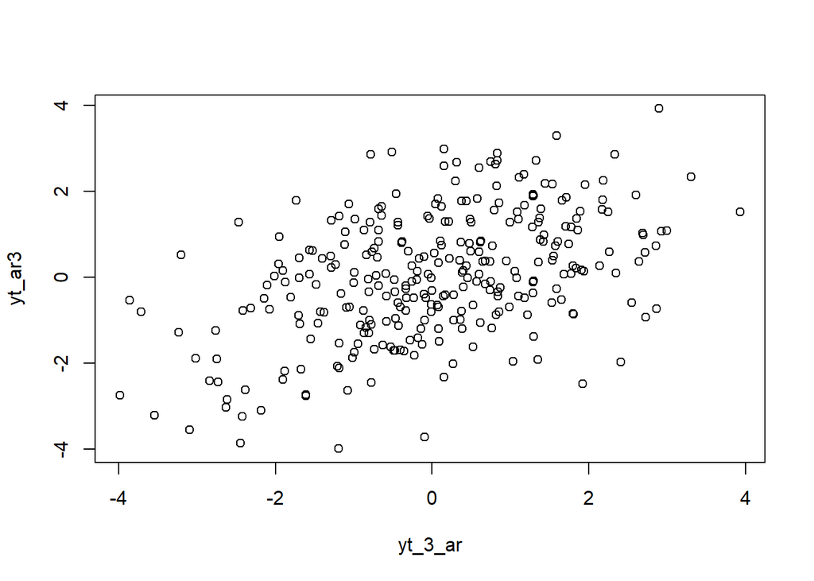

```r
plot(y=yt_ar3,x=yt_3_ar)
```

Berdasarkan Scatter plot tersebut, terlihat bahwa terdapat hubungan positif antara $Y_t$ dengan $Y_{t-3}$.

```r
cor(yt_ar3,yt_3_ar)
```

```
## [1] 0.4630342
```

Korelasi antara $Y_t$ dengan $Y_{t-3}$ mendekati perhitungan teoritis yaitu

$$\rho_3=\phi_1\rho_{k-1}+\phi_2\rho_{k-2}=\phi_1\rho_2+\phi_2\rho_1=0.5\times0.5125+0.2\times0.625=0.38125$$

# White Noise ARMA

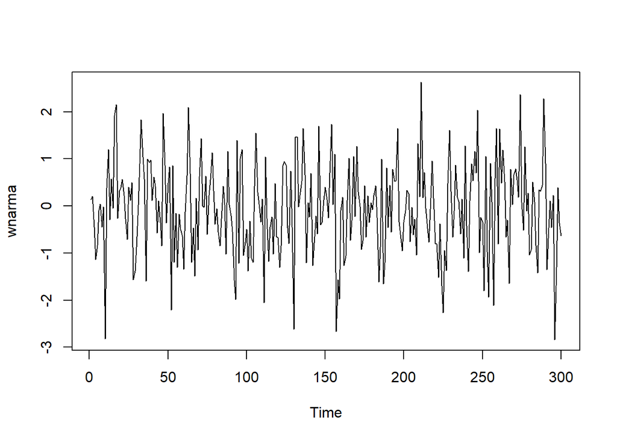

```r
set.seed(1241)
wnarma <- rnorm(300)
ts.plot(wnarma)
```

# ARMA(2,2)

Model ARMA(2,2) akan menggunakan data sebanyak 300 data. Model akan memiliki nilai $\phi_1 = 0.5$, $\phi_2 = 0.2$, $\theta_1 = 0.4$ dan $\theta_2 = 0.6$. Berikut merupakan model ARMA(2,2) yang akan digunakan

$$Y_t =
0.5Y_{t-1}+0.2Y_{t-2}+e_t-0.4_{t-1}-0.6_{t-2}$$

```r
phi1 = 0.5
phi2 = 0.2
theta1 = 0.4
theta2 = 0.6

y.arma=c(1:300)
for (i in 3:300){y.arma[i] = phi1*y.arma[i-1] + phi2*y.arma[i-2] +
                 wnarma[i] - theta1*wnarma[i-1] - theta2*wnarma[i-2]}
y.arma
```

```
##   [1]  1.00000000  2.00000000  0.58995380 -0.38702852 -0.19043342  0.75022200
##   [7]  0.91493086  0.20415097  0.41893446 -2.30180606  0.45835263  2.50502345
##  [13]  0.34873577  0.64933368  0.28809503  1.86469474  2.40328583 -0.69741039
##  [19] -0.73348850 -0.08812596  0.02993237 -0.24223433 -0.82059163 -1.18917623
##  [25]  0.09190977  0.18577402  0.32051197 -1.63746446 -1.80904480 -0.61115839
##  [31]  0.53323495  1.55935956  2.34343370  1.25448341  0.16119800 -2.12353544
##  [37]  0.25156286  1.18757968  0.65550497 -0.26154047 -0.01636235  0.04009751
##  [43] -1.08921766 -0.44723359 -0.49170738 -1.11370383  1.85914897  1.29848537
##  [49] -0.86555351 -0.06245226  0.64569144 -2.52224824  0.11170517 -0.66482932
##  [55] -0.49551302 -0.90067677 -0.11393503  0.11756991 -0.30550037 -0.92074450
##  [61]  0.27692692  1.45432305  2.69344778  1.10386347 -1.63753318 -0.99958523
##  [67] -1.40838661  0.13721416 -0.32090368  0.76956450  2.05817702  0.23829397
##  [73] -0.35397301  0.51020549 -0.65610300 -0.14376219  0.63108526  1.06163426
##  [79]  0.18670932 -0.89152756 -0.49679215 -0.72530318 -1.05792728 -0.26894036
##  [85]  0.69264378  0.31897150 -0.99068913  1.11897140  0.53581549 -0.41748782
```

[output cut: 35 more lines]

Model ARMA(2,2) dapat juga dibangkitkan dengan menggunakan fungsi `arima.sim()`

```r
arma22 <- arima.sim(list(order=c(2,0,2), ar = c(0.5,0.2), ma = c(0.4,0.6)), n=300)
arma22
```

```
## Time Series:
## Start = 1
## End = 300
## Frequency = 1
##   [1]  2.799116492  2.687306896  3.832492794  3.067282357  3.856000468
##   [6]  2.491607019  2.730231397  0.772061444 -0.512333888 -2.856939176
##  [11] -0.938855996 -0.303942607  0.722040917  0.605685091 -0.454931376
##  [16] -0.087504041 -1.626024649 -0.448262260 -1.387896995 -0.696583972
##  [21] -0.509770047  1.789509984  1.252564168  3.019009303  1.081752699
##  [26] -0.559804971  0.187810811  1.008617028  3.307958722  1.885031748
##  [31]  0.617521532 -0.688381321 -1.509802148 -2.941911378 -4.485685213
##  [36] -4.949431220 -3.395452799 -3.355760070 -1.159467590 -2.039383631
##  [41] -1.839314186 -0.866356490 -0.194047458  2.212806900  2.621172833
##  [46]  2.309803885  2.158917047  2.019603931 -0.745412194 -0.806566748
##  [51] -3.571504264 -1.936277508 -2.911164522 -0.169357146  0.355093796
```

[output cut: 49 more lines]

## Karakteristik ARMA(2,2)

### Plot DW ARMA(2,2)

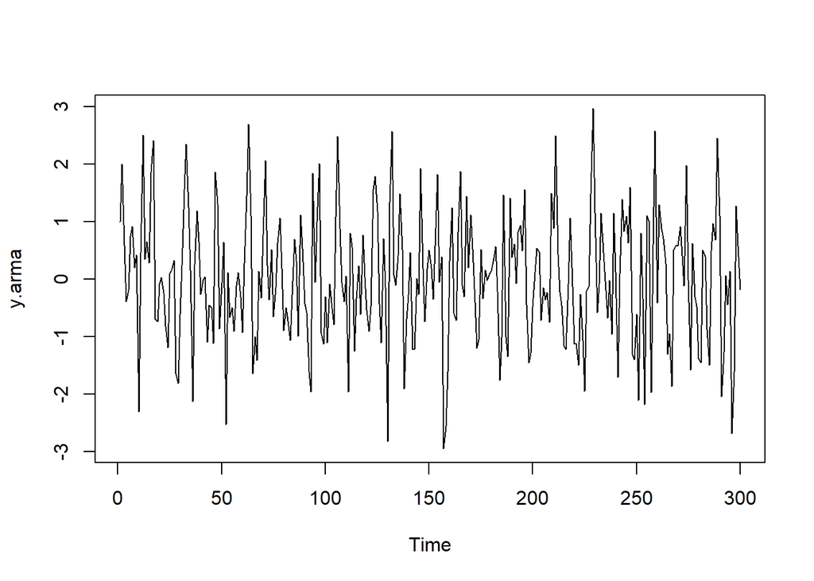

```r
ts.plot(y.arma)
```

Plot deret waktu menunjukkan bahwa data ARMA(2,2) stasioner pada rataan

### Plot ACF ARMA(2,2)

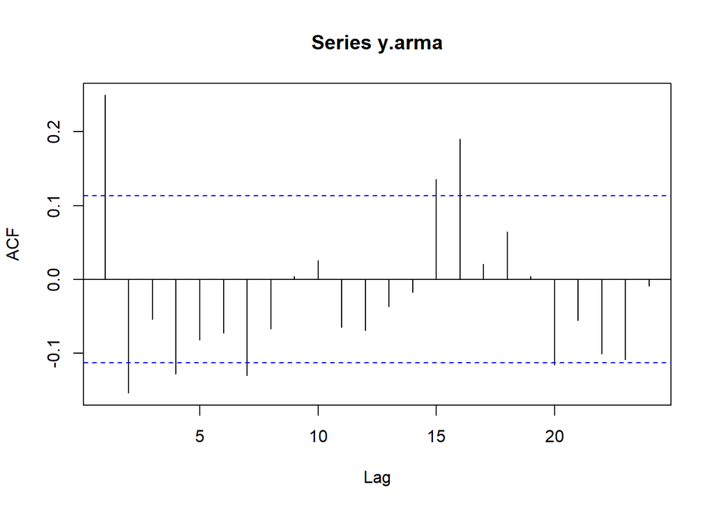

```r
acf(y.arma)
```

Plot ACF menunjukkan bahwa model ARMA(2,2) memiliki plot ACF yang *tails off*

### Plot PACF ARMA(2,2)

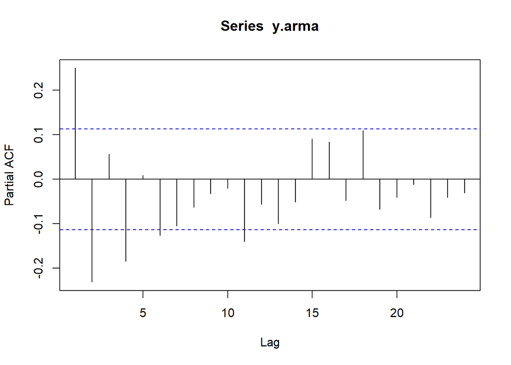

```r
pacf(y.arma)
```

Plot PACF menunjukkan bahwa model ARMA(2,2) memiliki plot PACF yang *tails off* juga

### Plot EACF ARMA(2,2)

```r
eacf(y.arma)
```

```
## AR/MA
##   0 1 2 3 4 5 6 7 8 9 10 11 12 13
## 0 x x o x o o x o o o o  o  o  o
## 1 x x o o o o o o o o o  o  o  o
## 2 x x o o o o o o o o o  o  o  o
## 3 x x x o o o o o o o o  o  o  o
## 4 o x x x o o o o o o o  o  o  o
## 5 o x x x x o o o o o o  o  o  o
## 6 x x o o x x x o o o o  o  o  o
## 7 x o o o x o x o o o o  o  o  o
```

Plot EACF memperlihatkan bahwa pola segitiga nol berada pada ordo AR(2) dan ordo MA(2)

### Scatter plot Antar Lag untuk ARMA(2,2)

#### $Y_t$ dengan $Y_{t-1}$

```r
yt_arma <- y.arma[-1]
yt_arma
```

```
##   [1]  2.00000000  0.58995380 -0.38702852 -0.19043342  0.75022200  0.91493086
##   [7]  0.20415097  0.41893446 -2.30180606  0.45835263  2.50502345  0.34873577
##  [13]  0.64933368  0.28809503  1.86469474  2.40328583 -0.69741039 -0.73348850
##  [19] -0.08812596  0.02993237 -0.24223433 -0.82059163 -1.18917623  0.09190977
##  [25]  0.18577402  0.32051197 -1.63746446 -1.80904480 -0.61115839  0.53323495
##  [31]  1.55935956  2.34343370  1.25448341  0.16119800 -2.12353544  0.25156286
##  [37]  1.18757968  0.65550497 -0.26154047 -0.01636235  0.04009751 -1.08921766
##  [43] -0.44723359 -0.49170738 -1.11370383  1.85914897  1.29848537 -0.86555351
##  [49] -0.06245226  0.64569144 -2.52224824  0.11170517 -0.66482932 -0.49551302
##  [55] -0.90067677 -0.11393503  0.11756991 -0.30550037 -0.92074450  0.27692692
##  [61]  1.45432305  2.69344778  1.10386347 -1.63753318 -0.99958523 -1.40838661
##  [67]  0.13721416 -0.32090368  0.76956450  2.05817702  0.23829397 -0.35397301
##  [73]  0.51020549 -0.65610300 -0.14376219  0.63108526  1.06163426  0.18670932
##  [79] -0.89152756 -0.49679215 -0.72530318 -1.05792728 -0.26894036  0.69264378
##  [85]  0.31897150 -0.99068913  1.11897140  0.53581549 -0.41748782 -0.57736624
```

[output cut: 35 more lines]

```r
yt_1_arma <- y.arma[-300]
yt_1_arma
```

```
##   [1]  1.00000000  2.00000000  0.58995380 -0.38702852 -0.19043342  0.75022200
##   [7]  0.91493086  0.20415097  0.41893446 -2.30180606  0.45835263  2.50502345
##  [13]  0.34873577  0.64933368  0.28809503  1.86469474  2.40328583 -0.69741039
##  [19] -0.73348850 -0.08812596  0.02993237 -0.24223433 -0.82059163 -1.18917623
##  [25]  0.09190977  0.18577402  0.32051197 -1.63746446 -1.80904480 -0.61115839
##  [31]  0.53323495  1.55935956  2.34343370  1.25448341  0.16119800 -2.12353544
##  [37]  0.25156286  1.18757968  0.65550497 -0.26154047 -0.01636235  0.04009751
##  [43] -1.08921766 -0.44723359 -0.49170738 -1.11370383  1.85914897  1.29848537
##  [49] -0.86555351 -0.06245226  0.64569144 -2.52224824  0.11170517 -0.66482932
##  [55] -0.49551302 -0.90067677 -0.11393503  0.11756991 -0.30550037 -0.92074450
##  [61]  0.27692692  1.45432305  2.69344778  1.10386347 -1.63753318 -0.99958523
##  [67] -1.40838661  0.13721416 -0.32090368  0.76956450  2.05817702  0.23829397
##  [73] -0.35397301  0.51020549 -0.65610300 -0.14376219  0.63108526  1.06163426
##  [79]  0.18670932 -0.89152756 -0.49679215 -0.72530318 -1.05792728 -0.26894036
##  [85]  0.69264378  0.31897150 -0.99068913  1.11897140  0.53581549 -0.41748782
```

[output cut: 35 more lines]

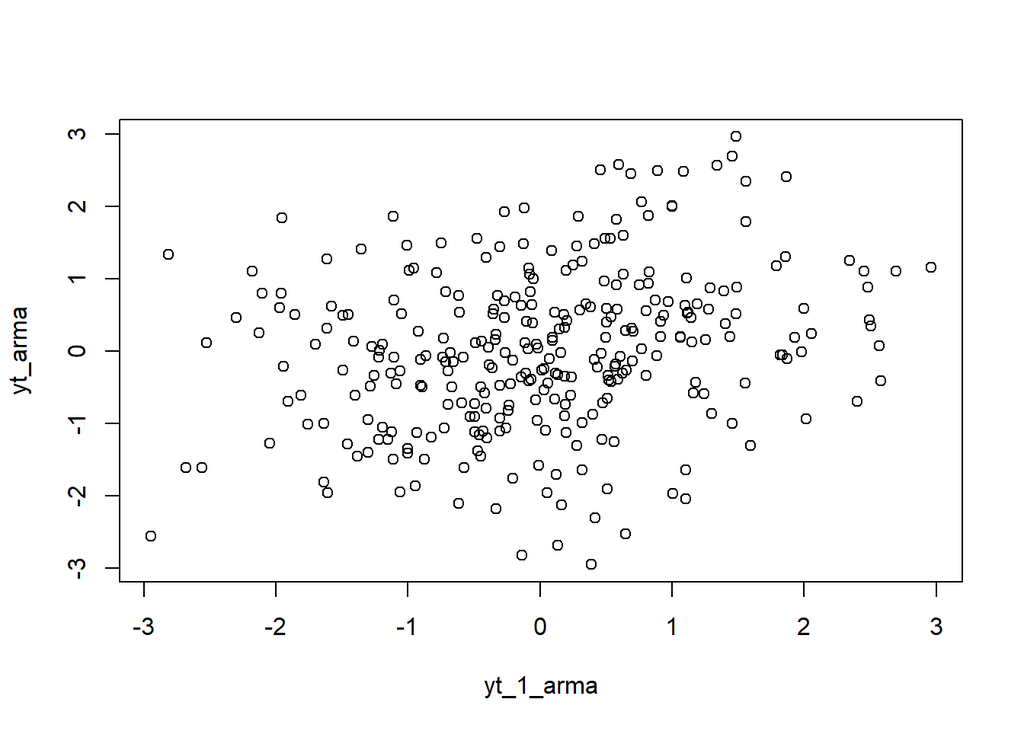

```r
plot(y=yt_arma,x=yt_1_arma)
```

Berdasarkan Scatter plot tersebut, terlihat bahwa terdapat hubungan positif antara $Y_t$ dengan $Y_{t-1}$.

```r
cor(yt_arma,yt_1_arma)
```

```
## [1] 0.2498057
```

#### $Y_t$ dengan $Y_{t-2}$

```r
yt_arma <- y.arma[-c(1,2)]
yt_arma
```

```
##   [1]  0.58995380 -0.38702852 -0.19043342  0.75022200  0.91493086  0.20415097
##   [7]  0.41893446 -2.30180606  0.45835263  2.50502345  0.34873577  0.64933368
##  [13]  0.28809503  1.86469474  2.40328583 -0.69741039 -0.73348850 -0.08812596
##  [19]  0.02993237 -0.24223433 -0.82059163 -1.18917623  0.09190977  0.18577402
##  [25]  0.32051197 -1.63746446 -1.80904480 -0.61115839  0.53323495  1.55935956
##  [31]  2.34343370  1.25448341  0.16119800 -2.12353544  0.25156286  1.18757968
##  [37]  0.65550497 -0.26154047 -0.01636235  0.04009751 -1.08921766 -0.44723359
##  [43] -0.49170738 -1.11370383  1.85914897  1.29848537 -0.86555351 -0.06245226
##  [49]  0.64569144 -2.52224824  0.11170517 -0.66482932 -0.49551302 -0.90067677
##  [55] -0.11393503  0.11756991 -0.30550037 -0.92074450  0.27692692  1.45432305
##  [61]  2.69344778  1.10386347 -1.63753318 -0.99958523 -1.40838661  0.13721416
##  [67] -0.32090368  0.76956450  2.05817702  0.23829397 -0.35397301  0.51020549
##  [73] -0.65610300 -0.14376219  0.63108526  1.06163426  0.18670932 -0.89152756
##  [79] -0.49679215 -0.72530318 -1.05792728 -0.26894036  0.69264378  0.31897150
##  [85] -0.99068913  1.11897140  0.53581549 -0.41748782 -0.57736624 -1.60867263
```

[output cut: 35 more lines]

```r
yt_2_arma <- y.arma[-c(299,300)]
yt_2_arma
```

```
##   [1]  1.00000000  2.00000000  0.58995380 -0.38702852 -0.19043342  0.75022200
##   [7]  0.91493086  0.20415097  0.41893446 -2.30180606  0.45835263  2.50502345
##  [13]  0.34873577  0.64933368  0.28809503  1.86469474  2.40328583 -0.69741039
##  [19] -0.73348850 -0.08812596  0.02993237 -0.24223433 -0.82059163 -1.18917623
##  [25]  0.09190977  0.18577402  0.32051197 -1.63746446 -1.80904480 -0.61115839
##  [31]  0.53323495  1.55935956  2.34343370  1.25448341  0.16119800 -2.12353544
##  [37]  0.25156286  1.18757968  0.65550497 -0.26154047 -0.01636235  0.04009751
##  [43] -1.08921766 -0.44723359 -0.49170738 -1.11370383  1.85914897  1.29848537
##  [49] -0.86555351 -0.06245226  0.64569144 -2.52224824  0.11170517 -0.66482932
##  [55] -0.49551302 -0.90067677 -0.11393503  0.11756991 -0.30550037 -0.92074450
##  [61]  0.27692692  1.45432305  2.69344778  1.10386347 -1.63753318 -0.99958523
##  [67] -1.40838661  0.13721416 -0.32090368  0.76956450  2.05817702  0.23829397
##  [73] -0.35397301  0.51020549 -0.65610300 -0.14376219  0.63108526  1.06163426
##  [79]  0.18670932 -0.89152756 -0.49679215 -0.72530318 -1.05792728 -0.26894036
##  [85]  0.69264378  0.31897150 -0.99068913  1.11897140  0.53581549 -0.41748782
```

[output cut: 35 more lines]

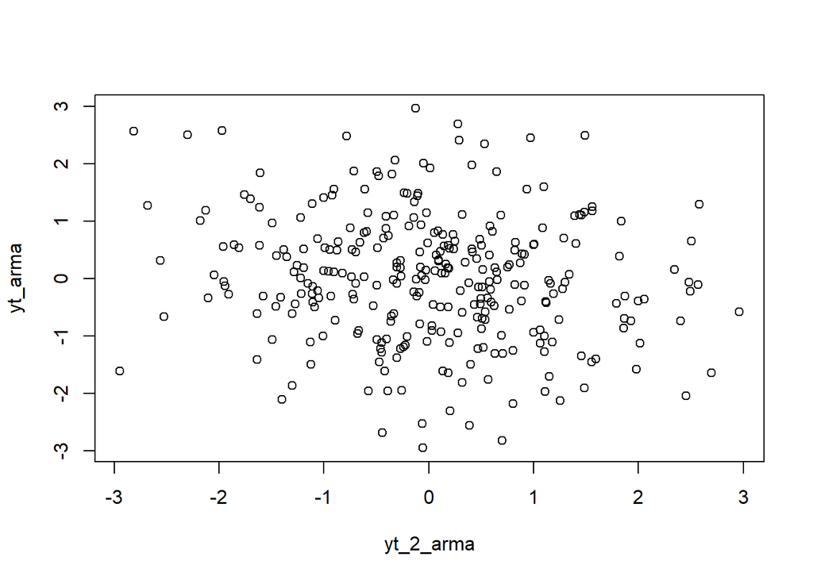

```r
plot(y=yt_arma,x=yt_2_arma)
```

Berdasarkan Scatter plot tersebut, terlihat bahwa terdapat hubungan negatif antara $Y_t$ dengan $Y_{t-2}$.

```r
cor(yt_arma,yt_2_arma)
```

```
## [1] -0.1551224
```

#### $Y_t$ dengan $Y_{t-3}$

```r
yt_arma <- y.arma[-c(1,2,3)]
yt_arma
```

```
##   [1] -0.38702852 -0.19043342  0.75022200  0.91493086  0.20415097  0.41893446
##   [7] -2.30180606  0.45835263  2.50502345  0.34873577  0.64933368  0.28809503
##  [13]  1.86469474  2.40328583 -0.69741039 -0.73348850 -0.08812596  0.02993237
##  [19] -0.24223433 -0.82059163 -1.18917623  0.09190977  0.18577402  0.32051197
##  [25] -1.63746446 -1.80904480 -0.61115839  0.53323495  1.55935956  2.34343370
##  [31]  1.25448341  0.16119800 -2.12353544  0.25156286  1.18757968  0.65550497
##  [37] -0.26154047 -0.01636235  0.04009751 -1.08921766 -0.44723359 -0.49170738
##  [43] -1.11370383  1.85914897  1.29848537 -0.86555351 -0.06245226  0.64569144
##  [49] -2.52224824  0.11170517 -0.66482932 -0.49551302 -0.90067677 -0.11393503
##  [55]  0.11756991 -0.30550037 -0.92074450  0.27692692  1.45432305  2.69344778
##  [61]  1.10386347 -1.63753318 -0.99958523 -1.40838661  0.13721416 -0.32090368
##  [67]  0.76956450  2.05817702  0.23829397 -0.35397301  0.51020549 -0.65610300
##  [73] -0.14376219  0.63108526  1.06163426  0.18670932 -0.89152756 -0.49679215
##  [79] -0.72530318 -1.05792728 -0.26894036  0.69264378  0.31897150 -0.99068913
##  [85]  1.11897140  0.53581549 -0.41748782 -0.57736624 -1.60867263 -1.95512498
```

[output cut: 35 more lines]

```r
yt_3_arma <- y.arma[-c(298,299,300)]
yt_3_arma
```

```
##   [1]  1.00000000  2.00000000  0.58995380 -0.38702852 -0.19043342  0.75022200
##   [7]  0.91493086  0.20415097  0.41893446 -2.30180606  0.45835263  2.50502345
##  [13]  0.34873577  0.64933368  0.28809503  1.86469474  2.40328583 -0.69741039
##  [19] -0.73348850 -0.08812596  0.02993237 -0.24223433 -0.82059163 -1.18917623
##  [25]  0.09190977  0.18577402  0.32051197 -1.63746446 -1.80904480 -0.61115839
##  [31]  0.53323495  1.55935956  2.34343370  1.25448341  0.16119800 -2.12353544
##  [37]  0.25156286  1.18757968  0.65550497 -0.26154047 -0.01636235  0.04009751
##  [43] -1.08921766 -0.44723359 -0.49170738 -1.11370383  1.85914897  1.29848537
##  [49] -0.86555351 -0.06245226  0.64569144 -2.52224824  0.11170517 -0.66482932
##  [55] -0.49551302 -0.90067677 -0.11393503  0.11756991 -0.30550037 -0.92074450
##  [61]  0.27692692  1.45432305  2.69344778  1.10386347 -1.63753318 -0.99958523
##  [67] -1.40838661  0.13721416 -0.32090368  0.76956450  2.05817702  0.23829397
##  [73] -0.35397301  0.51020549 -0.65610300 -0.14376219  0.63108526  1.06163426
##  [79]  0.18670932 -0.89152756 -0.49679215 -0.72530318 -1.05792728 -0.26894036
##  [85]  0.69264378  0.31897150 -0.99068913  1.11897140  0.53581549 -0.41748782
```

[output cut: 35 more lines]

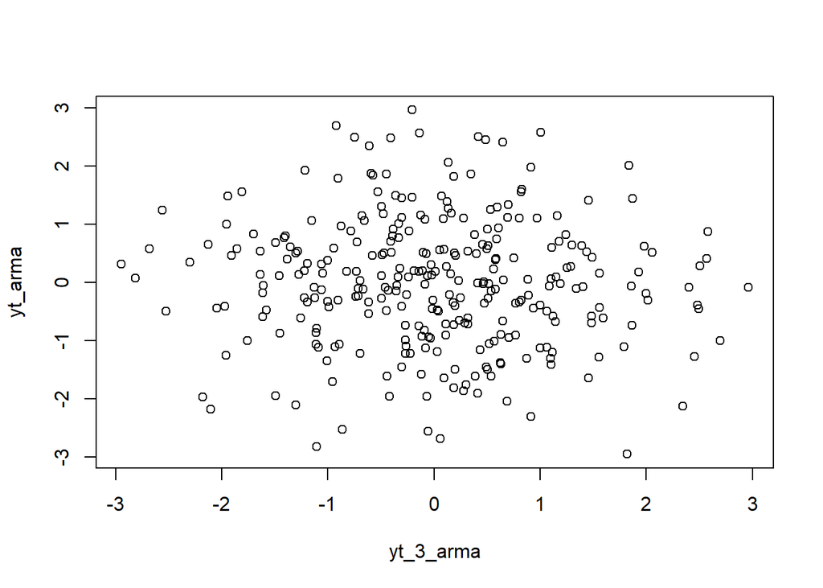

```r
plot(y=yt_arma,x=yt_3_arma)
```

```r
cor(yt_arma,yt_3_arma)
```

```
## [1] -0.05494691
```